# (Ford GoBike System data Exploration )

## Dataset Overview

### Distribution of trip duration

##### Duration of bike trips in the dataset take on a very large range of values, from about 1 minute to 24 hours, and was measured on seconds.

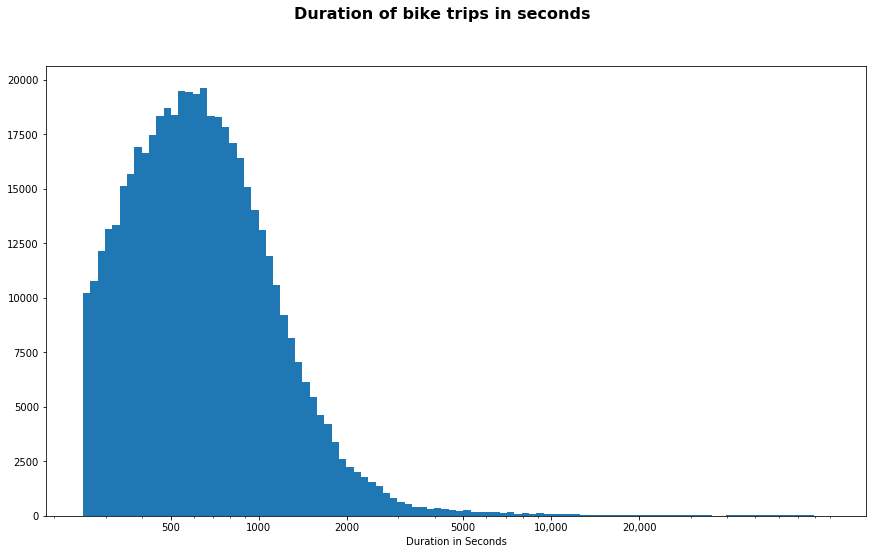

```python
plt.figure(figsize=[14.70, 8.27])
log_binsize = 0.025
bins = 10 ** np.arange(2.4, np.log10(Three_months_df['Duration in Seconds'].max())+log_binsize, log_binsize)
plt.hist(data = Three_months_df, x = 'Duration in Seconds', bins = bins)
plt.xscale('log')
plt.xticks([500, 1e3, 2e3, 5e3, 1e4, 2e4], [500, '1000', '2000', '5000', '10,000', '20,000'])
plt.xlabel('Duration in Seconds')
plt.suptitle('Duration of bike trips in seconds', fontsize=16, fontweight="bold")

plt.show();
```

### Exploring the median age member of bike renters

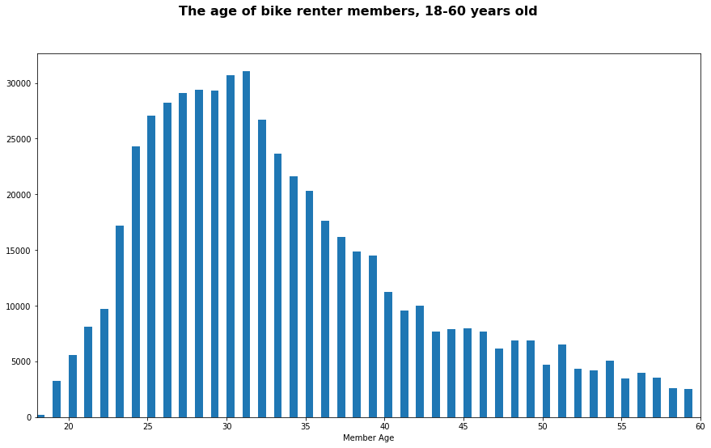

```python
binsize = 0.5
bins = np.arange(0, Three_months_df['member_age'].max()+binsize, binsize)
plt.figure(figsize=[14.70, 8.27])
plt.hist(data = Three_months_df, x = 'member_age', bins = bins)
plt.xlim([18,60])
plt.xlabel('Member Age')
plt.suptitle('The age of bike renter members, 18-60 years old', fontsize=16, fontweight="bold")
plt.show();
```

### Distribution of different categorical varials in the dataset.

#### Like; the gender, type of customer, starting day of the week, and whether or not the trip was shared.

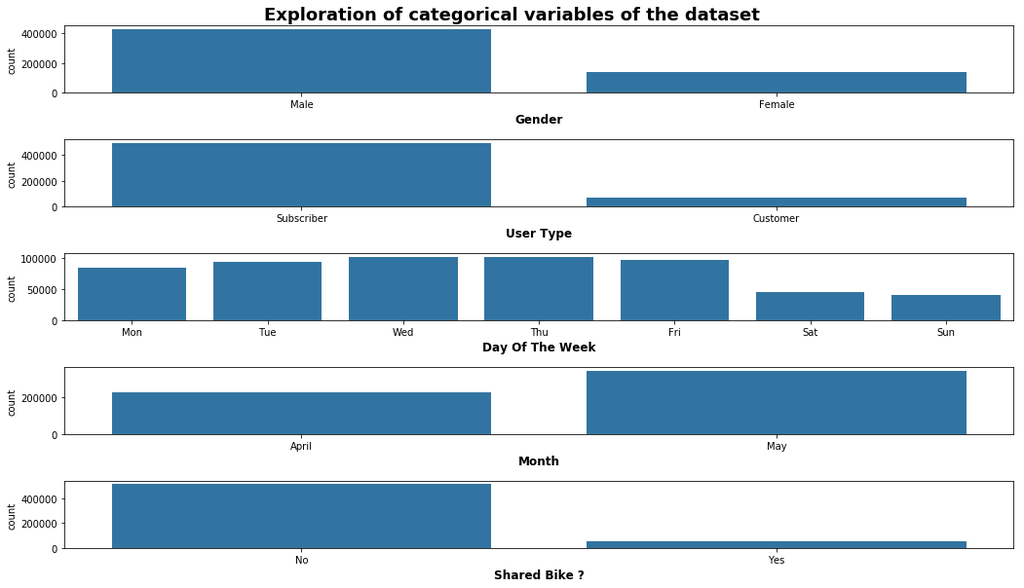

```python
# let's plot the 2 variables together to get an idea of each ordinal variable's distribution.

fig, ax = plt.subplots(nrows=5, figsize=[14.70, 8.27])

default_color = sb.color_palette()[0]
sb.countplot(data = Three_months_df, x = 'member_gender', color = default_color, ax = ax[0])
ax[0].set_xlabel('Gender'.title(), fontsize = 12, weight = "bold")

sb.countplot(data = Three_months_df, x = 'user_type', color = default_color, ax = ax[1])
ax[1].set_xlabel('User Type'.title(), fontsize = 12, weight = "bold")

sb.countplot(data = Three_months_df, x = 'start_time_weekday', color = default_color, ax = ax[2])
ax[2].set_xlabel('Day of the week'.title(), fontsize = 12, weight = "bold")

sb.countplot(data = Three_months_df, x = 'start_month', color = default_color, ax = ax[3])
ax[3].set_xlabel('Month'.title(), fontsize = 12, weight = "bold")

sb.countplot(data = Three_months_df, x = 'bike_share_for_all_trip', color = default_color, ax = ax[4])
ax[4].set_xlabel('Shared bike ?'.title(), fontsize = 12, weight = "bold")

plt.suptitle('Exploration of categorical variables of the dataset', fontsize=18, fontweight="bold", y = 1.01)
plt.tight_layout()
plt.show();
```

#### Male users are more than the females, as well as the subscribers number is way higher than the customer user_type. Moreover, interstingly, Thursday is the peak day among all weekdays. Also, May has more bike renters than April, that maybe due to the weather getting better. Also, most of the trips were not shared.

### The correlation between the numeric variables of the dataset

#### The follwing plots to demonstrater the relationship between different numeric variables, like; trip duration in seconds, member age, the start month, day , and hour of the trip.

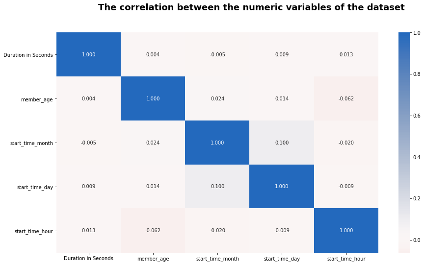

```python
# correlation plot
plt.figure(figsize=[14.70, 8.27])

sb.heatmap(Three_months_df[numeric_vars].corr(), annot = True, fmt = '.3f',
           cmap = 'vlag_r', center = 0)
plt.suptitle('The correlation between the numeric variables of the dataset', fontsize=18, fontweight="bold")
plt.show();
```

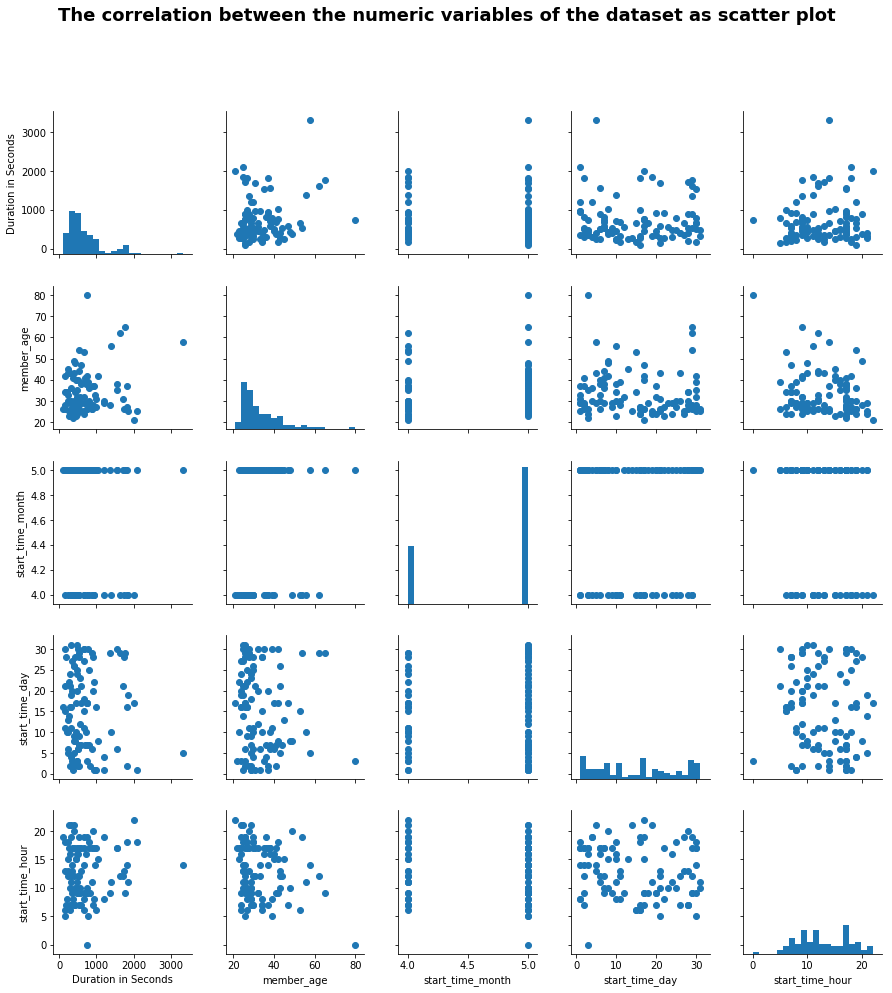

```python
# plot matrix: sample 100 records so that plots are clearer and
# they render faster
plt.figure(figsize=[14.70, 8.27])
samples = np.random.choice(Three_months_df.shape[0], 100, replace = False)
trip_samp = Three_months_df.loc[samples,:]

graph = sb.PairGrid(data = trip_samp, vars = numeric_vars)
graph = graph.map_diag(plt.hist, bins = 20);
graph.map_offdiag(plt.scatter)
plt.tight_layout()
graph.fig.suptitle('The correlation between the numeric variables of the dataset as scatter plot', y = 1.1, fontsize=18, fontweight='semibold');
```

##### Also, there is a correlatopn between the trip start_time day and the trip start_time month.

### The correlation between (member's age and the duration of the bike trips) and other catigorical variales in the dataset.

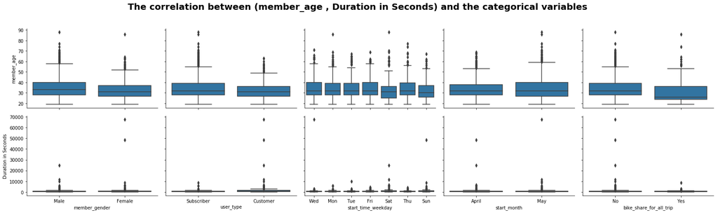

```python
# plot matrix of numeric features against categorical features.
plt.figure(figsize=[14.70, 8.27])
samples = np.random.choice(Three_months_df.shape[0], 2000, replace = False)
trip_samp = Three_months_df.loc[samples,:]

def boxgrid(x, y, **kwargs):
    """ Quick hack for creating box plots with seaborn's PairGrid. """
    default_color = sb.color_palette()[0]
    sb.boxplot(x, y, color = default_color)


graph = sb.PairGrid(data = trip_samp, y_vars = ['member_age', 'Duration in Seconds'], x_vars = categoric_vars,
                height = 3, aspect = 1.5)

graph.map(boxgrid)

graph.fig.suptitle('The correlation between (member_age , Duration in Seconds) and the categorical variables ', y = 1.1, fontsize=20, fontweight='semibold');
plt.tight_layout()

plt.show();
```

### The relationships between the following categorical features; member_gender, user_type, start_time_weekday

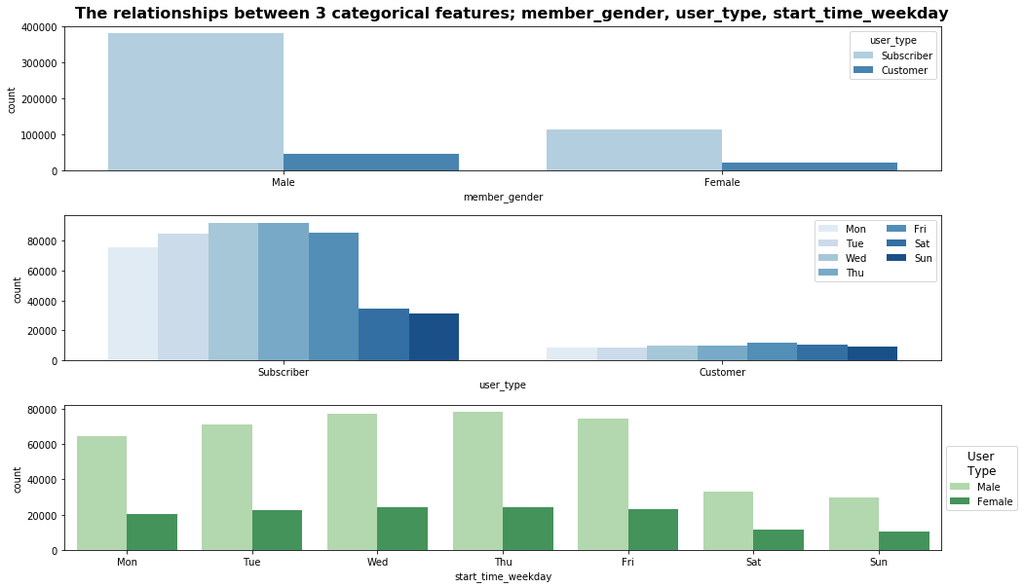

```python
# since there's only three subplots to create, using the full data should be fine.
plt.figure(figsize=[14.70, 8.27])

# subplot 1: member_gender vs user_type

plt.subplot(3, 1, 1)
sb.countplot(data = Three_months_df, x = 'member_gender', hue = 'user_type', palette = 'Blues')

# subplot 2: user_type vs. start_time_weekday
ax = plt.subplot(3, 1, 2)

sb.countplot(data = Three_months_df, x = 'user_type', hue = 'start_time_weekday', palette = 'Blues')
ax.legend(ncol = 2) # re-arrange legend to reduce overlapping

# subplot 3: start_time_weekday vs. member_gender, use different color palette
ax = plt.subplot(3, 1, 3)
sb.countplot(data = Three_months_df, x = 'start_time_weekday', hue = 'member_gender', palette = 'Greens')
ax.legend(loc = 1, ncol = 2) # re-arrange legend to remove overlapping

plt.suptitle('The relationships between 3 categorical features; member_gender, user_type, start_time_weekday', y=1.01, fontsize=16, fontweight="bold")
plt.legend(loc='center left', bbox_to_anchor=(1, 0.5),
           title="User\nType", title_fontsize = 12);
plt.tight_layout()
plt.show();
```

#### we may interpret; Fridays get more customer user type than the other days, while Wednesdays and Thursdays are mpre poplar among the subscribers. The weekends ( Saturdays and Sundays) have the least number of bike renters

### The gender of each user type

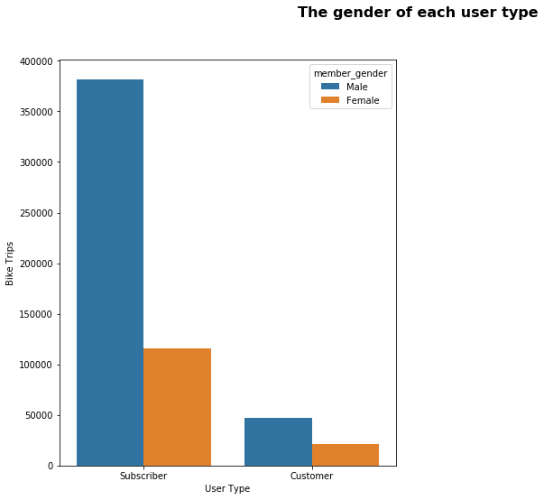

```python
plt.figure(figsize=[14.70, 8.27])
plt.subplot(1, 2, 1)

gragh = sb.countplot(data = Three_months_df, x = "user_type", hue = "member_gender", order = Three_months_df.user_type.value_counts().index)
gragh.set_xlabel('User Type')
plt.suptitle('The gender of each user type', fontsize=16, fontweight="bold")


gragh.set_ylabel('Bike Trips');
```

#### Generally, male useres are more than the female users.

### Exploring how the gender of the user and the type of the user relate to the day of the week that they have rent the bike.

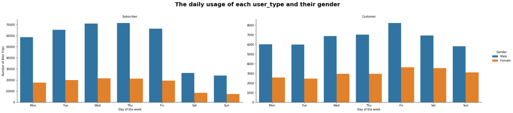

```python
weekday = ['Mon', 'Tue', 'Wed', 'Thu', 'Fri', 'Sat', 'Sun']

gragh = sb.catplot(data = Three_months_df, x = 'start_time_weekday', col = "user_type", hue = 'member_gender', kind = 'count', sharey = False,
                order = weekday, aspect = (14.70/3)/(8.27/4))
gragh.set_axis_labels("Day of the week", "Number of Bike Trips")
gragh._legend.set_title('Gender')
plt.suptitle('The daily usage of each user_type and their gender', fontsize=20, fontweight="semibold", y = 1.1)


gragh.set_titles("{col_name}");
```

### The hourly usage of each user_type throughout the week

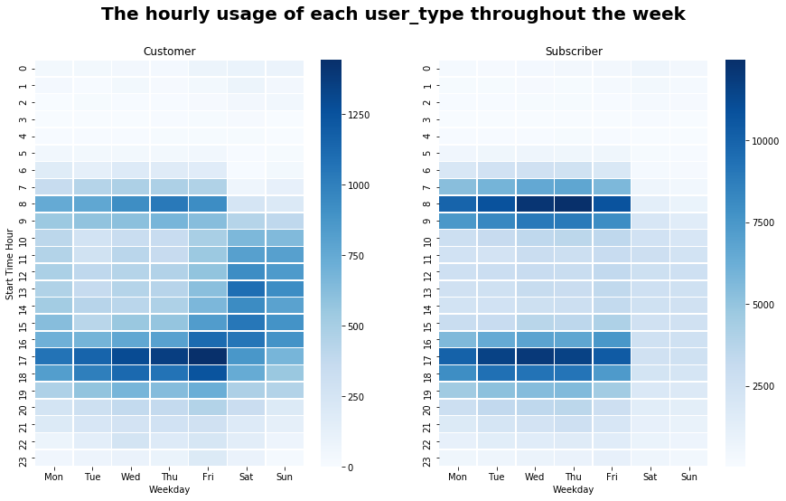

```python
Three_months_df['start_time_weekday'] = pd.Categorical(Three_months_df['start_time_weekday'],
                                                categories=['Mon','Tue','Wed','Thu','Fri','Sat', 'Sun'],
                                                ordered=True)
plt.figure(figsize=[14.70, 8.27])

# creating heatmap for customers
plt.subplot(1, 2, 1)
df_customer = Three_months_df.query('user_type == "Customer"').groupby(["start_time_hour", "start_time_weekday"])["bike_id"].size().reset_index()
df_customer = df_customer.pivot("start_time_hour", "start_time_weekday", "bike_id")
sb.heatmap(df_customer, cmap="Blues",linewidths=.5 )

plt.title("Customer", y=1)
plt.xlabel('Weekday')
plt.ylabel('Start Time Hour')

# creating heatmap for subscribers
plt.subplot(1, 2, 2)
df_subscriber = Three_months_df.query('user_type == "Subscriber"').groupby(["start_time_hour", "start_time_weekday"])["bike_id"].size().reset_index()
df_subscriber = df_subscriber.pivot("start_time_hour", "start_time_weekday", "bike_id")
sb.heatmap(df_subscriber, cmap="Blues",linewidths=.5)

plt.title("Subscriber", y = 1)
plt.xlabel('Weekday')
plt.suptitle('The hourly usage of each user_type throughout the week', fontsize=20, fontweight="semibold")

plt.ylabel('');
```

#### We may notice now that among subscribers, between 7-9AM and 5-6pm are the most poplar hours. From that we may derive that most of the subscribers are employees.

#### While costomers, have peek in the evenings (5-7 pm). Those maybe just casual renters and want to cruise the city after working hours.